# Categorical data plots

If one of the main variables is “categorical” (divided into discrete groups) it may be helpful to use a more specialized approach to visualization.

Ref: https://seaborn.pydata.org/tutorial/categorical.html

Categorical plots belong in 3 different families:

- Categorical estimate plots:
  - pointplot() (with kind="point")
  - barplot() (with kind="bar")
  - countplot() (with kind="count")
- Categorical distribution plots:
  - boxplot() (with kind="box")
  - violinplot() (with kind="violin")
  - boxenplot() (with kind="boxen")
- Categorical scatterplots:
  - stripplot() (with kind="strip"; the default)
  - swarmplot() (with kind="swarm")

avilable seaborn style are: darkgrid , whitegrid , dark , white , and ticks

```python
import seaborn as sns
%matplotlib inline
```

```python
#Load dataset

tips = sns.load_dataset('tips')
tips.head()
```

|  | total_bill | tip | sex | smoker | day | time | size |
| --- | --- | --- | --- | --- | --- | --- | --- |
| 0 | 16.99 | 1.01 | Female | No | Sun | Dinner | 2 |
| 1 | 10.34 | 1.66 | Male | No | Sun | Dinner | 3 |
| 2 | 21.01 | 3.50 | Male | No | Sun | Dinner | 3 |
| 3 | 23.68 | 3.31 | Male | No | Sun | Dinner | 2 |
| 4 | 24.59 | 3.61 | Female | No | Sun | Dinner | 4 |

## barplot and countplot

barplot is a general plot that allows to aggregate the categorical data based on some function, by default the mean.

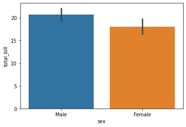

```python
sns.barplot(x='sex',y='total_bill',data=tips)
```

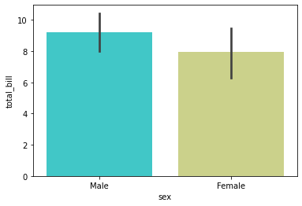

```python
#adding estimator: Statistical function to estimate within each categorical bin.
import numpy as np
sns.barplot(x='sex',y='total_bill',data=tips, estimator=np.std,palette='rainbow')
```

## countplot

It is same as the barplot except the estimator is explicitly counting the number of occurrences. Hence we are going to pass only the x value.

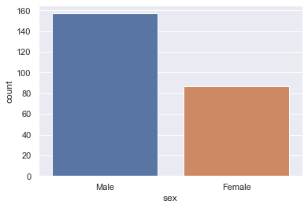

```python
sns.countplot(x='sex', data=tips)
```

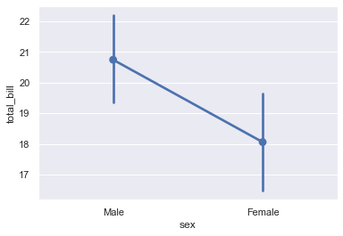

```python
#Show point estimates and confidence intervals using scatter plot glyphs.
# avilable theme style: darkgrid , whitegrid , dark , white , and ticks
sns.set_theme(style='darkgrid')
sns.pointplot(x='sex',y='total_bill',data=tips)
```

## boxplot and violin plot

- boxplots and violinplots are used to shown the distribution of categorical data.
- A box plot (or box-and-whisker plot) shows the distribution of quantitative data in a way that facilitates comparisons between variables or across levels of a categorical variable. The box shows the quartiles of the dataset while the whiskers extend to show the rest of the distribution, except for points that are determined to be "outliers" using a method that is a function of the inter-quartile range.

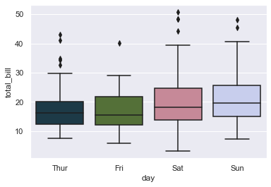

```python
sns.boxplot(x='day',y='total_bill',data=tips,palette='cubehelix')
```

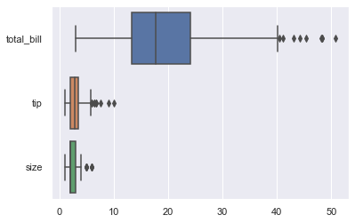

```python
#boxplot of entire dataframe with horizontal orientation
sns.boxplot(data=tips,orient='h')
```

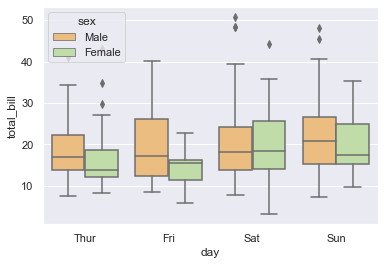

```python
#Boxplot with hue
sns.boxplot(x='day',y='total_bill',data=tips,hue='sex',palette='Spectral')
```

## Violin plot

- Draw a combination of boxplot and kernel density estimate.
- A violin plot plays a similar role as a box and whisker plot.
- Violin plot shows the distribution of quantitative data across several levels of one (or more) categorical variables such that those distributions can be compared

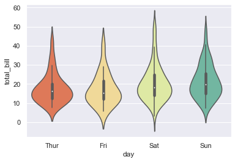

```python
#sns.violinplot(x='day', y='total_bill', data=tips, palette='Spectral')
sns.violinplot(x='day',y='total_bill',data=tips,palette='Spectral')
```

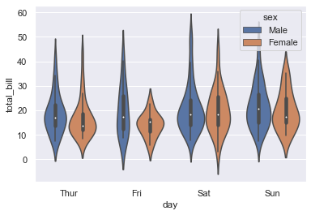

```python
#violinplot with hue
sns.violinplot(x='day',y='total_bill',hue='sex',data=tips)
```

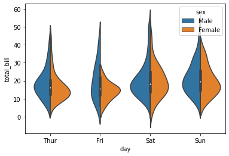

```python
#violinplot with split option set True
sns.violinplot(x='day',y='total_bill',hue='sex',data=tips,split=True)
```

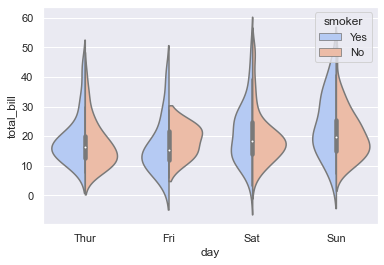

```python
#violinplot with hue
sns.violinplot(x='day',y='total_bill',hue='smoker',data=tips,split=True,palette='coolwarm')
```

## stripplot and swarmplot

The stripplot draws a scatterplot where one variable is categorical. A strip plot can be drawn on its own, but it is also a good complement to a box or violin plot

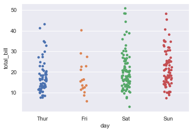

```python
sns.stripplot(x='day',y='total_bill',data=tips)
```

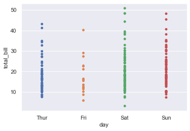

```python
#stripplot with jitter set to False
sns.stripplot(x='day',y='total_bill',data=tips,jitter=False)
```

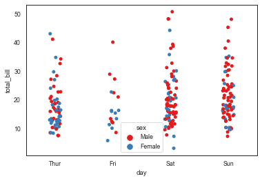

```python
#striplot with hue
sns.set_theme(context='paper',style='white')
sns.stripplot(x='day',y='total_bill',data=tips,hue='sex',palette='Set1')
```

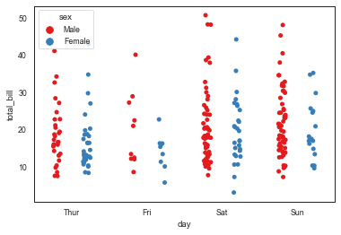

```python
#striplot with hue an dodge (split) option to be set
sns.stripplot(x='day',y='total_bill',data=tips,hue='sex',dodge=True, palette='Set1')
```

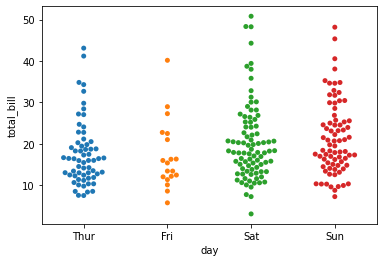

```python
#Swarmplot
#Draw a categorical scatterplot with non-overlapping points.
sns.swarmplot(x='day',y='total_bill',data=tips)
```

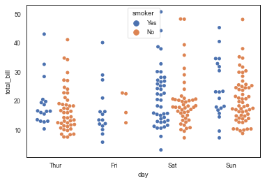

```python
#Swarmplot with hue and dodge  set
sns.swarmplot(x='day',y='total_bill',data=tips,hue='smoker',dodge=True)
```

## Combining categorial plot (violinplot and sripplot)

```python
#look at the data set again
tips.head()
```

|  | total_bill | tip | sex | smoker | day | time | size |
| --- | --- | --- | --- | --- | --- | --- | --- |
| 0 | 16.99 | 1.01 | Female | No | Sun | Dinner | 2 |
| 1 | 10.34 | 1.66 | Male | No | Sun | Dinner | 3 |
| 2 | 21.01 | 3.50 | Male | No | Sun | Dinner | 3 |
| 3 | 23.68 | 3.31 | Male | No | Sun | Dinner | 2 |
| 4 | 24.59 | 3.61 | Female | No | Sun | Dinner | 4 |

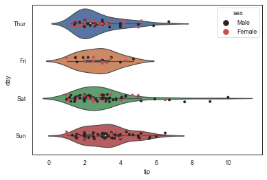

```python
sns.violinplot(x='tip',y='day',data=tips)
sns.stripplot(x='tip',y='day',data=tips,color='r',size=4,hue='sex')
```

## catplot() with kind option

You can also use catplot() with kind option to create the above plots as well. It is generic version of creating different categorical plots by setting different *kind* option values.

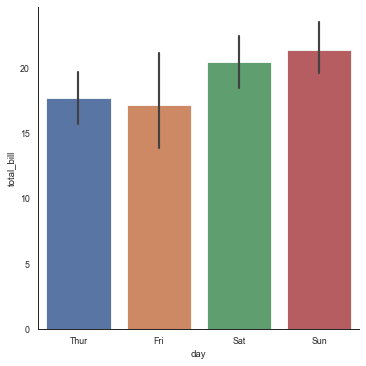

```python
#catplot with kind is bar
sns.catplot(x='day',y='total_bill',data=tips, kind='bar')
```

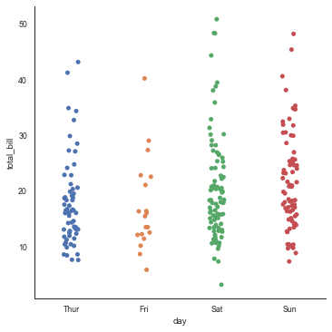

```python
#catplot with kind is strip
sns.catplot(x='day',y='total_bill',kind='strip',data=tips)
```

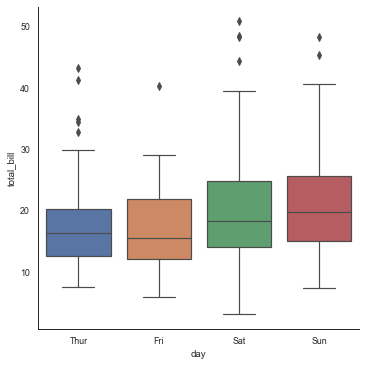

```python
#catplot with kind is box
sns.catplot(x='day',y='total_bill',kind='box',data=tips)
```

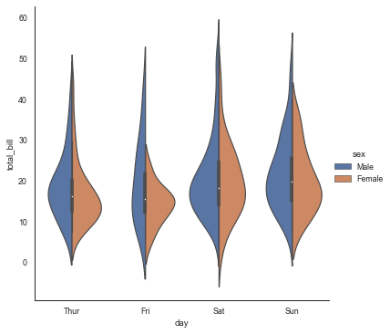

```python
#catplot with kind is box
sns.catplot(x='day',y='total_bill',kind='violin',data=tips,hue='sex',split=True)
```